# Assignment 16: Writing a function - Loop

*How to do it?*:

- Open the Rmarkdown file of this assignment (link) in Rstudio.
- Right under each **question**, insert a code chunk (you can use the hotkey `Ctrl + Alt + I` to add a code chunk) and code the solution for the question.
- `Knit` the rmarkdown file (hotkey: `Ctrl + Alt + K`) to export an html.
- Publish the html file to your Githiub Page.

*Submission*: Submit the link on Github of the assignment to Canvas

1. Write the following function. Give examples to test your function.
- Input: a data frame
- Output: a data frame with all the missing of numeric variables replaced by the associated means.

Hint: [Similar function](https://bryantstats.github.io/math421/gganimate/18_writing_functions.html#28)

```r
df_missing_func <- function(df) {
  for (i in seq_along(df)) {
    if (is.numeric(df[[i]])) {
      df[[i]] <- ifelse(is.na(df[[i]]), mean(df[[i]], na.rm = TRUE), df[[i]])
    }
  }
  return(df)
}
```

```r
example_df <- data.frame(
  A = c(1, 2, NA, 4, 5),
  B = c(NA, 2, 3, 4, 5),
  C = c("No", NA, "Yes", NA, "No")
)
new_example_df <- df_missing_func(example_df)

print(new_example_df)
```

```
##   A   B    C
## 1 1 3.5   No
## 2 2 2.0 <NA>
## 3 3 3.0  Yes
## 4 4 4.0 <NA>
## 5 5 5.0   No
```

2. Write the following function. Give examples to test your function.
- Input: a data frame
- Output: a data frame with all the missing of variables replaced by the associated means (for numeric variables) or modes (for non-numeric variables).

Hint: Use If-statement to combine the function in Problem 1 and the function in [this example](https://bryantstats.github.io/math421/gganimate/18_writing_functions.html#28)

```r
df_missing_func2 <- function(df) {
  library(zoo)
  for (i in seq_along(df)) {
    if (is.numeric(df[[i]])) {
      df[[i]] <- ifelse(is.na(df[[i]]), mean(df[[i]], na.rm = TRUE), df[[i]])
    }
    else if (!is.numeric(df[[i]])) {
      mode_val <- names(sort(-table(df[[i]])))[1]
      df[[i]] <- na.fill(df[[i]], fill = mode_val)
    }
  }
  return(df)
}
```

```r
example_df <- data.frame(
  A = c(1, 2, NA, 4, 5),
  B = c(NA, 2, 3, 4, 5),
  C = c("No", NA, "Yes", NA, "No")
)
new_example_df <- df_missing_func2(example_df)

print(new_example_df)
```

```
##   A   B   C
## 1 1 3.5  No
## 2 2 2.0  No
## 3 3 3.0 Yes
## 4 4 4.0  No
## 5 5 5.0  No
```

3. Write the following function. Give examples to test your function.
- Input: a data frame
- Output: Bar plots of all non-numeric variables

Hint: [Similar function](https://bryantstats.github.io/math421/gganimate/18_writing_functions.html#33)

```r
df_bar_plot <- function(df) {
  library(ggplot2)
  library(dplyr)

  for (col_name in names(df)) {
    if (!is.numeric(df[[col_name]])) {
      plot_object <- df %>%
        ggplot(aes(x = .data[[col_name]])) +
        geom_bar(fill = "dodgerblue")

      print(plot_object)
    }
  }
}
```

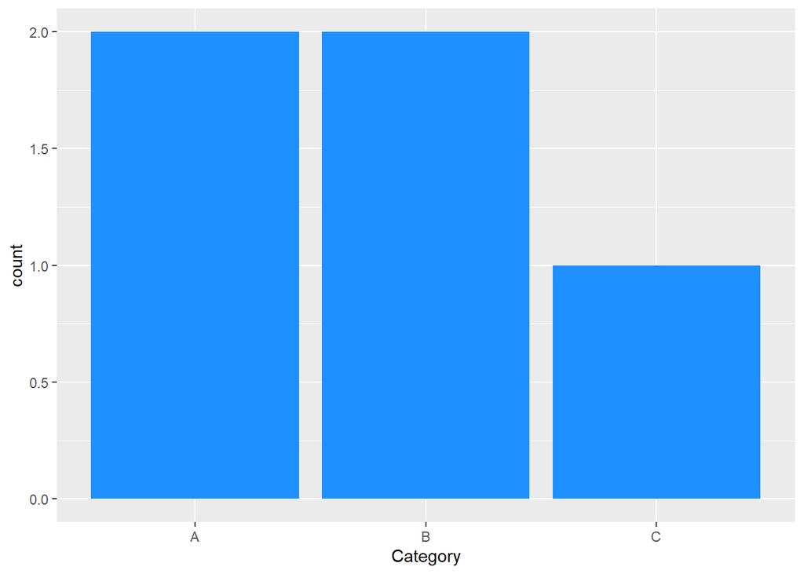

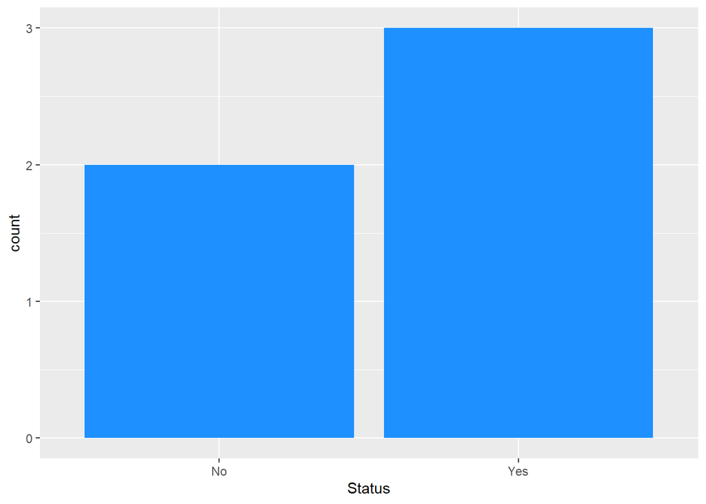

```r
example_df <- data.frame(
  Category = c("A", "B", "C", "A", "B"),
  Count = c(10, 15, 8, 12, 20),
  Status = c("Yes", "No", "Yes", "No", "Yes")
)

df_bar_plot(example_df)
```

4. Write the following function. Give examples to test your function.
- Input: a data frame
- Output: all possible the bar plots of a non-numeric variable filled by a non-numeric variable.

Hint: [Similar function](https://bryantstats.github.io/math421/gganimate/18_writing_functions.html#40)

```r
df_bar_plot2 <- function(df){
library(ggplot2)
  l <- length(df)
  for (i in 1:(l-1))
    for (j in (i+1):l)
  {
    if ((!is.numeric(df[[i]])) & (!is.numeric(df[[j]])))
    {
      print(ggplot(df, aes(x = df[[i]], fill = df[[j]])) +
              geom_bar(position = 'fill')+
              labs(x = names(df)[i], fill = names(df)[j]))
    }
  }
}
```

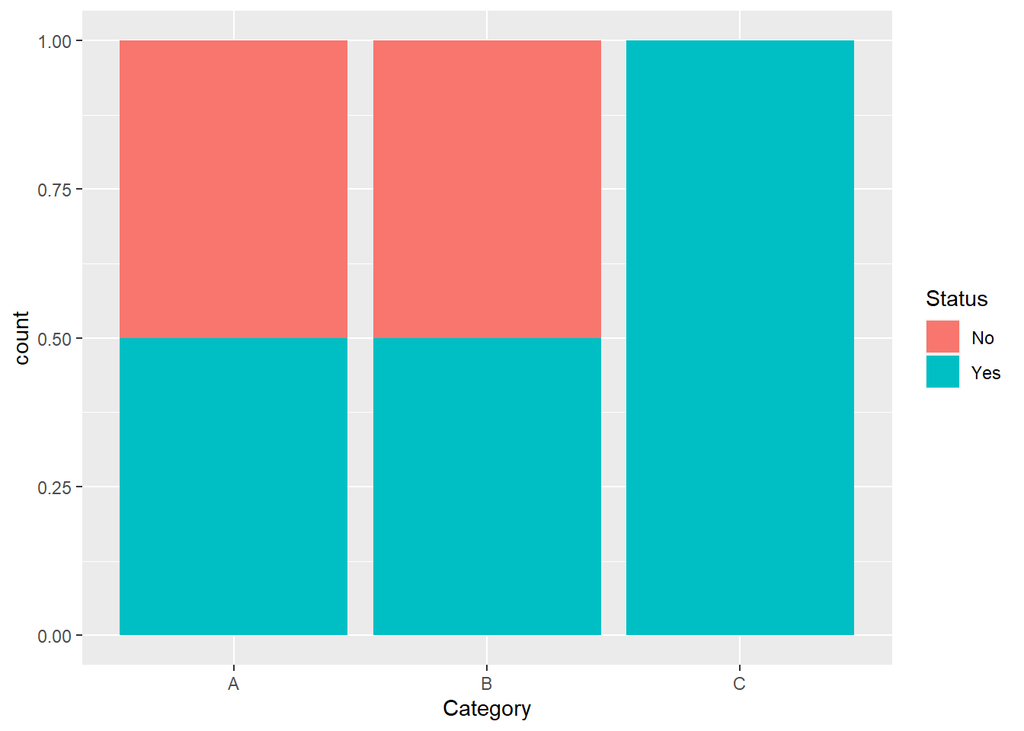

```r
example_df <- data.frame(
  Category = c("A", "B", "C", "A", "B"),
  Count = c(10, 15, 8, 12, 20),
  Status = c("Yes", "No", "Yes", "No", "Yes")
)

df_bar_plot2(example_df)
```

5. Write the following function. Give examples to test your function.
- Input: a data frame
- Output:
  - all possible the bar plots of a non-numeric variable filled by a non-numeric variable.
  - all possible the density plots of a numeric variable colored by a non-numeric variable
  - all possible the scatter plots.

Hint: Combine [this function](https://bryantstats.github.io/math421/gganimate/18_writing_functions.html#37), [this function](https://bryantstats.github.io/math421/gganimate/18_writing_functions.html#40), and the function in Question 4. One way to combine is creating a new function, `quick_plot`, and call these three functions within `quick_plot`.

```r
quick_plot <- function(df){
library(ggplot2)
  l <- length(df)
  for (i in 1:(l-1))
    for (j in (i+1):l)
  {
     if (is.numeric(df[[i]])&is.numeric(df[[j]]))
    {
      print(ggplot(df, aes(x = df[[i]], y = df[[j]]))+
              geom_point()+
              labs(x = names(df)[i], y = names(df)[j]))
     }
     else if (is.numeric(df[[i]])& (!is.numeric(df[[j]])))
    {
      print(ggplot(df, aes(x = df[[i]], color = df[[j]]))+
              geom_density()+labs(x = names(df)[i], color = names(df)[j]))
     }
      else if ((!is.numeric(df[[i]])) & (!is.numeric(df[[j]])))
    {
      print(ggplot(df, aes(x = df[[i]], fill = df[[j]])) +
              geom_bar(position = 'fill')+
              labs(x = names(df)[i], fill = names(df)[j]))
    }
  }
}
```

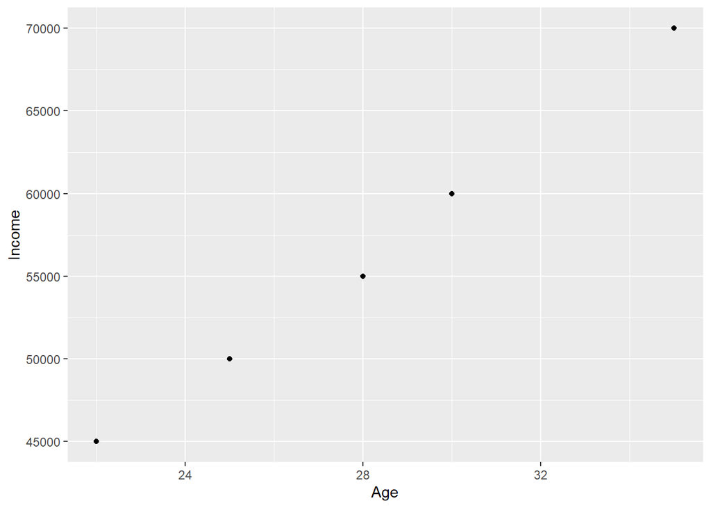

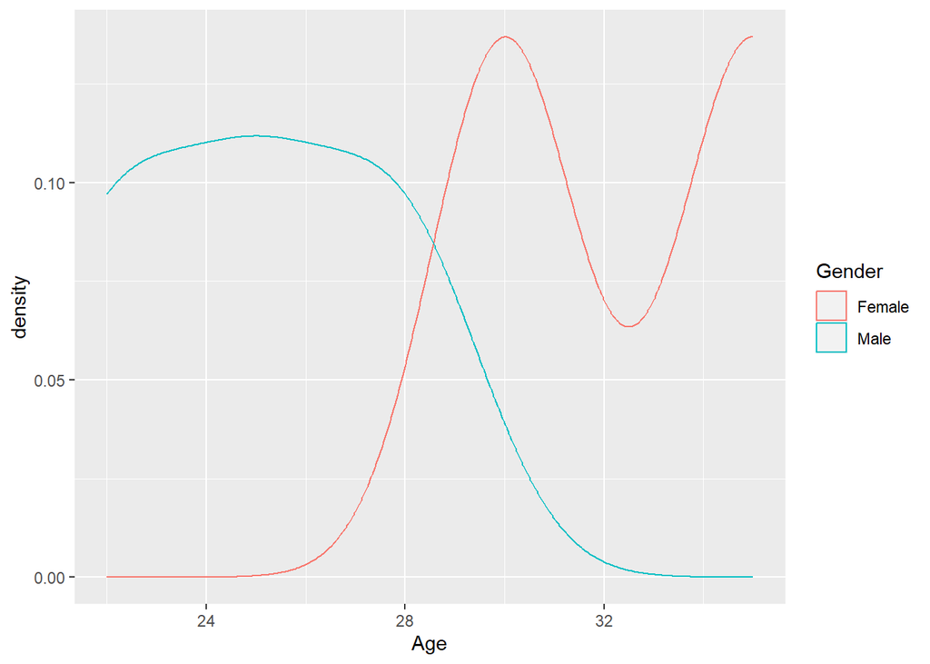

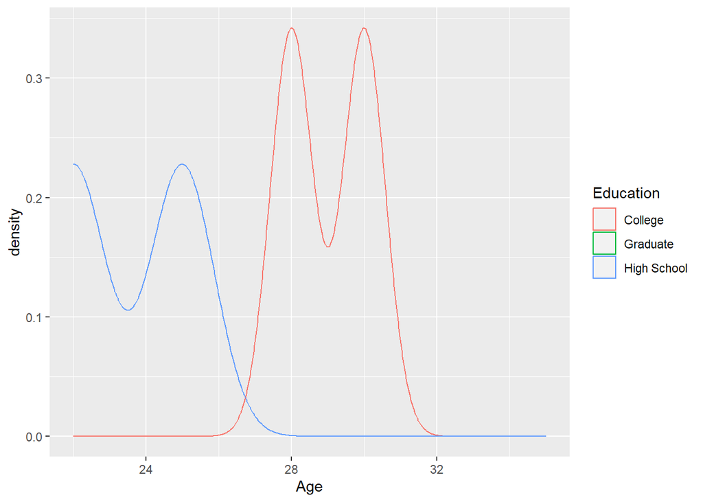

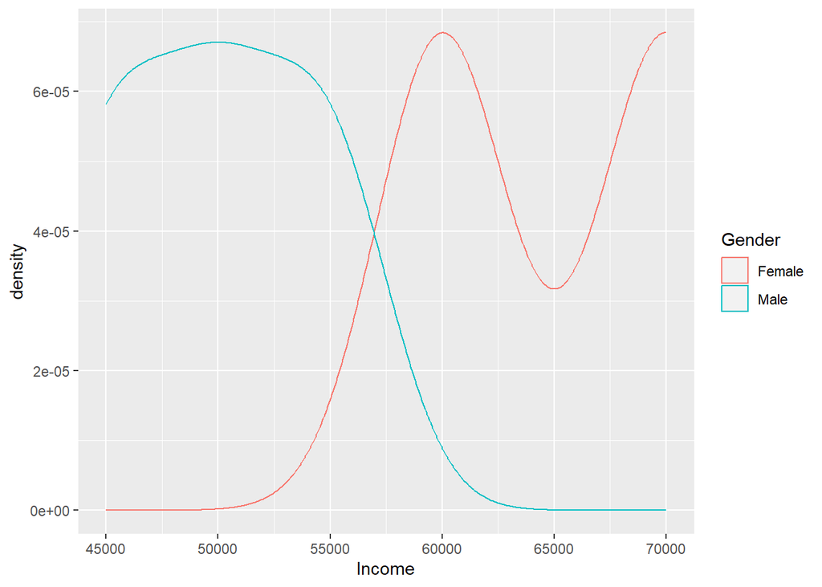

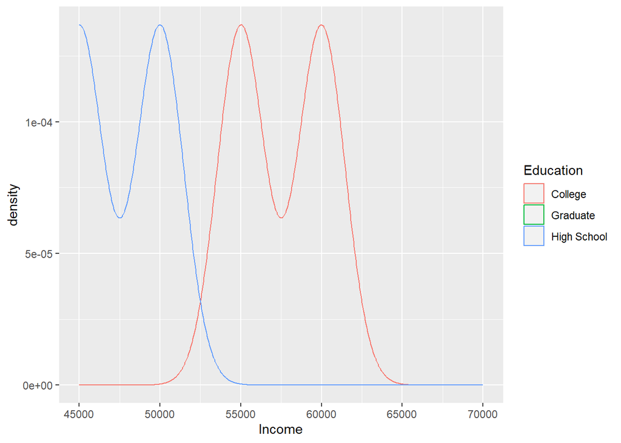

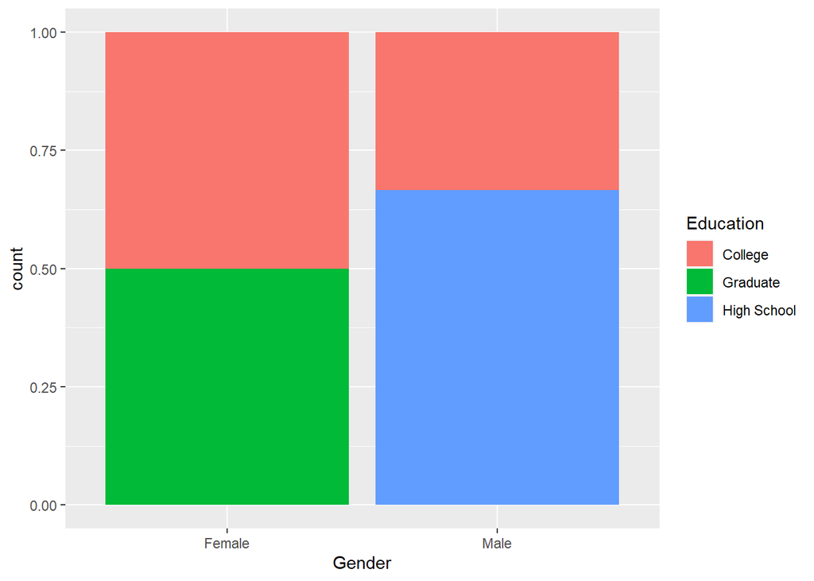

```r
example_df <- data.frame(
  Age = c(25, 30, 22, 35, 28),
  Income = c(50000, 60000, 45000, 70000, 55000),
  Gender = c("Male", "Female", "Male", "Female", "Male"),
  Education = c("High School", "College", "High School", "Graduate", "College")
)

quick_plot(example_df)
```